# ggplot2

Cameron Jones

Stat 240: Summer 2023

*Disclaimer: This material was presented briefly at in-person discussions as a brief recap of the week’s concepts during the Spring ’23 iteration of Stat 240. It is not a comprehensive list on everything you need to know for this topic.*

# Content Review: ggplot2

#### Our Data: Orange Tree Circumference vs. Age

```r
Orange[c(1:3, 8:10),] # "Orange" is one of many of R's built-in datasets! You can see them all using data(). Contains age and circumference measurements for five orange trees growing over time.
```

```
##    Tree age circumference
## 1     1 118            30
## 2     1 484            58
## 3     1 664            87
## 8     2 118            33
## 9     2 484            69
## 10    2 664           111
```

## Concept: One Variable Plots

One variable plots allow us to analyze the distribution of a single variable; here, we have 35 measurements of circumference from five different orange trees over time.

There are three typical choices:

- Histogram
- Density Plot
- Box Plot

In all of these graphs, one of the axes will be the variable we input, and the other axis will be some automatically generated count or density variable.

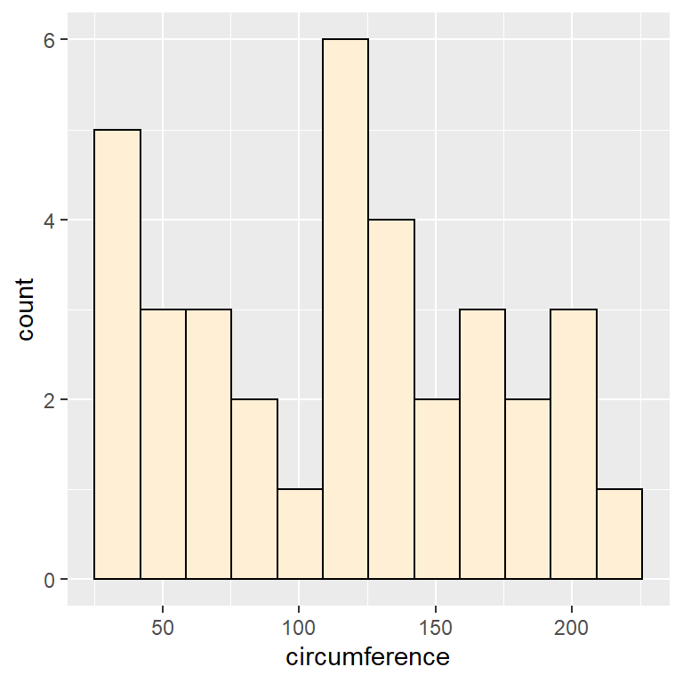

```r
ggplot(data = Orange, mapping = aes(x = circumference)) +
  geom_histogram(color = "black", fill = "papayawhip", bins = 12)
```

```r
  # Review on ggplot() syntax:

  # Start every plot with ggplot(data); often you will add aesthetics too, as above

  # Aesthetics are how you customize specific properties of the graph; sometimes they are variables from a dataframe, e.g. aes(x = circumference), and sometimes they are just specific number or color choices, like color = "red" or alpha = 0.5

  # If you include an aes() mapping in the original ggplot() call, as above, it will be used for all the following geom_*() functions

  # Notice that "constant" aesthetics (e.g. not variables) do NOT go in aes()
```

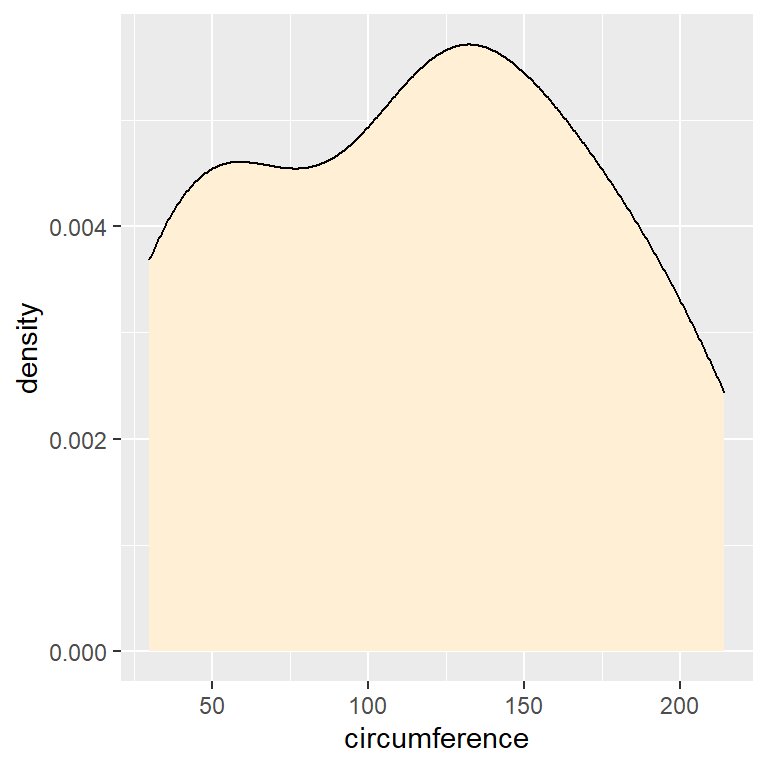

```r
ggplot(data = Orange, mapping = aes(x = circumference)) +
  geom_density(fill = "papayawhip")
```

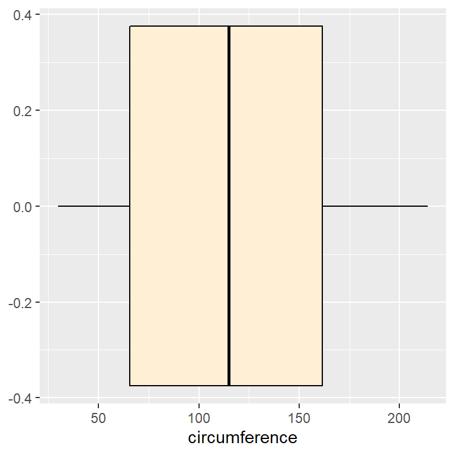

```r
ggplot(data = Orange, mapping = aes(x = circumference)) +
  geom_boxplot(color = "black", fill = "papayawhip")
```

## Concept: Two Variable Plots

In two variable plots, we look at the relationship between two variables. Each axis will be specified by a variable aesthetic and taken straight from the dataframe we provide. We very often use `geom_point` to create a scatter plot of two variables, and then overlay a connecting line with `geom_line` or a best fit regression line with `geom_smooth`.

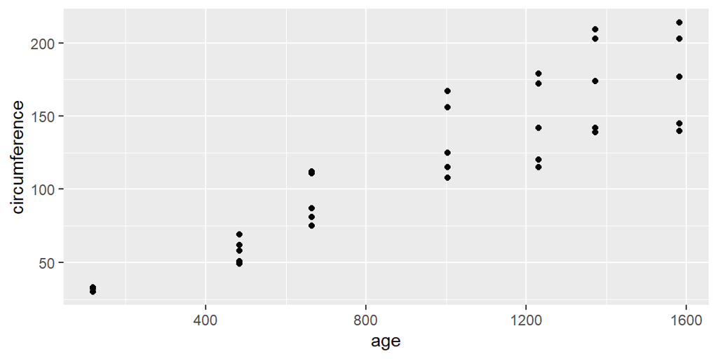

```r
ggplot(data = Orange, mapping = aes(x = age, y = circumference)) +
  geom_point()
```

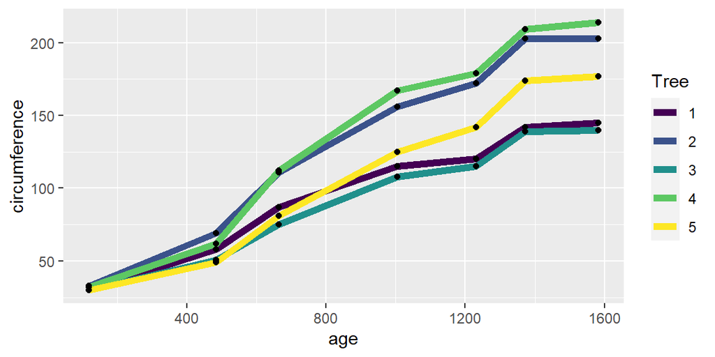

```r
ggplot(data = Orange, mapping = aes(x = age, y = circumference)) +
  geom_line(aes(color = Tree), size = 2) +
    geom_point() # Because aes(color = Tree) is in geom_line(), and not ggplot(), it only applies to the line; points remain black by default
```

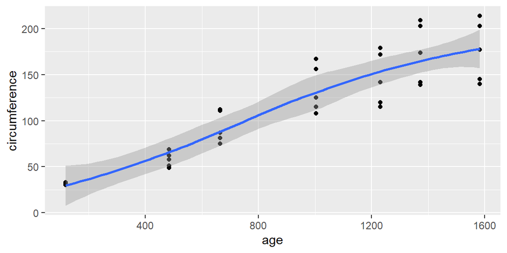

```r
ggplot(data = Orange, mapping = aes(x = age, y = circumference)) +
  geom_point() +
  geom_smooth()
```